# Jersey City Public Schools — NJ School Data Almanac – NJ District Profiles

NJ School Data Almanac

Jersey City Public Schools

HUDSON COUNTY · TRADITIONAL PUBLIC DISTRICT · DFG B · 25,307 STUDENTS (2026)

25,307

Students

78.3%

4-yr grad rate

45.4%

Gr 3-8 ELA

23.8%

Chronically absent

$22,219

Per pupil

*10 things the data says about Jersey City Public Schools. Every figure is computed from New Jersey Department of Education data via the njschooldata package — nothing is estimated. Comparisons use District Factor Group (DFG) peers (67 districts in DFG B).*

No. 1 ACHIEVEMENT

## Five Years After the Shutdown, Jersey City’s Elementary Math Proficiency Still Hasn’t Returned to 2017 Levels

On the NJSLA exam for grades 3-8, math proficiency cratered during the pandemic and, three rounds of testing later, sits below where it started a decade ago.

Jersey City’s youngest tested students recovered some ground after the pandemic, but math is the subject that has not come back. On the New Jersey Student Learning Assessment for grades 3 through 8, the district’s math proficiency fell from 34.2% in 2019 to 24.5% in 2022, a drop of nearly 10 percentage points when in-person testing resumed. It has climbed only modestly since, to 27.1% in 2023 and 29.3% in 2024.

That 29.3% is the part worth sitting with. It is not merely below the 2019 pre-pandemic mark of 34.2%; it is below the district’s 2017 figure of 30.9%, the earliest year in the data. Put plainly, more than seven years after the first measurement and four years after schools reopened, fewer Jersey City students in grades 3-8 are proficient in math than were before any of it began. Roughly seven in ten are still below grade level.

ELA has fared somewhat better but tells a related story: it peaked at 51.6% in 2019, fell to 41.9% in 2022, and has crept back to 45.4% by 2024, still 6.2 points shy of its own peak. The recovery is real but partial, and slower in math than in reading. The data cannot say whether the math plateau reflects curriculum, staffing, or the depth of the original loss, but it poses the question facing the district most directly: what changes when a child’s entire elementary math foundation was built during the years that never fully recovered?

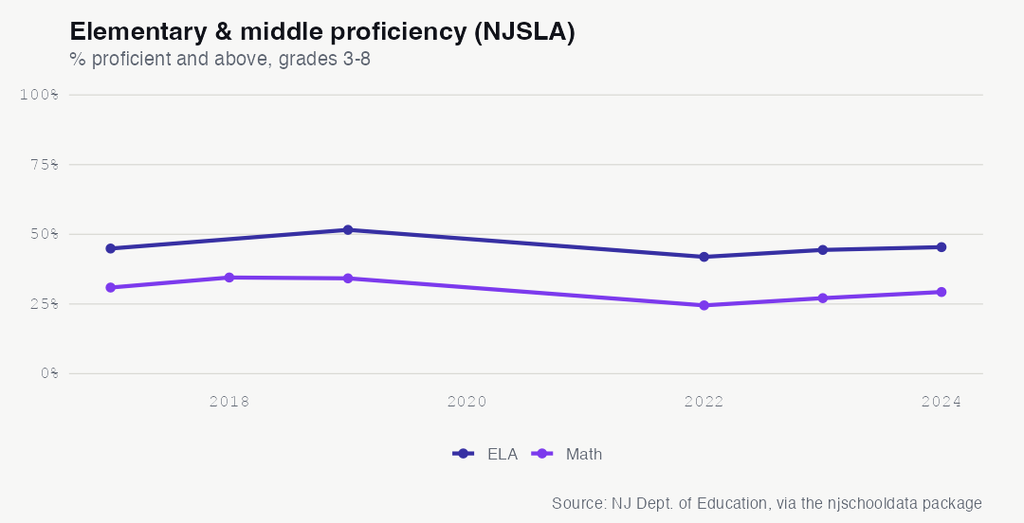

See the underlying data ›

No. 2 EQUITY

## In Jersey City’s Elementary and Middle Grades, 79% of Asian Students Are Proficient in Reading and 8% of Students With Disabilities Are

The 2024 NJSLA reading results for grades 3-8 reveal a proficiency range of more than 70 points across student groups within the same district.

Jersey City’s overall NJSLA reading proficiency of 45.4% for grades 3-8 in 2024 conceals one of the widest internal ranges in this entire dataset. At the top, 79.1% of students who are Asian met or exceeded proficiency, followed by 60.0% of students who are not economically disadvantaged and 54.4% of students who are white.

At the bottom, the numbers fall away sharply. Among students who are Black, 25.8% were proficient; among students who are economically disadvantaged, 34.7%; among students who are Hispanic, the district’s largest group, 38.2%. Lowest of all were students in special education at 7.7% and multilingual learners at 13.8%. The distance between students who are Asian (79.1%) and students in special education (7.7%) is 71.4 percentage points within a single school system.

The white-Black gap alone is 28.6 points, and the gap between students who are and are not economically disadvantaged is 25.3 points. These divides appear in grades 3-8, years before the graduation gaps that show up later in high school, suggesting the patterns are set early. The data cannot say what closes them, but it locates the work in elementary classrooms, not just senior year.

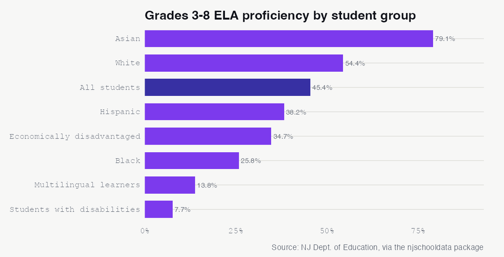

See the underlying data ›

No. 3 FINANCE

## Jersey City Spends $22,219 Per Pupil, in the 92nd Percentile of Its Peers, While Graduating in the 10th

The district outspends nearly all of its socioeconomic peers per student, even as its graduation rate sits near the bottom of the same group.

Among the 67 districts in its District Factor Group, Jersey City is one of the highest spenders. Its 2024 per-pupil figure of $22,219 ranks in the 92nd percentile, well above the peer median of $18,001, a difference of roughly $4,200 per student. Spending has risen 18.1% since 2014, when it stood at $18,807.

The contrast with outcomes is the story. The same peer group in which Jersey City spends near the top is the one in which it graduates near the bottom, at the 10th percentile with a 78.3% rate against a 91.0% median. High spending and high graduation usually travel together within a peer band; here they pull in opposite directions.

Of the money spent, 56.2% went to classroom instruction in 2025, with 16.9% to plant operations, 15.1% to support services and 10.0% to administration. The figures do not explain why dollars and diplomas diverge so sharply, but they sharpen the question every Jersey City taxpayer can ask: what is the spending buying, if not a graduation rate to match?

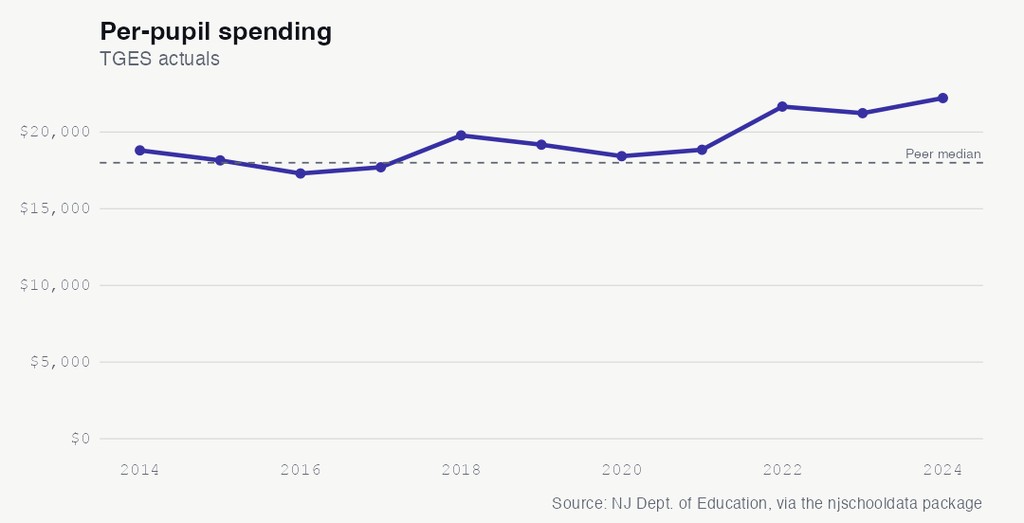

See the underlying data ›

No. 4 GRADUATION

## Jersey City’s 78% Graduation Rate Ranks in the 10th Percentile Among Its 67 Peer Districts

A rate that has barely moved in six years sits nearly 13 percentage points below the typical district in Jersey City’s socioeconomic band.

Jersey City graduated 78.3% of its class of 2025 within four years. Measured against the district’s own past, that is roughly where it has sat for years: 77.3% in 2020, 78.0% in 2021 and 2022, a high of 80.1% in 2023, then 77.7% in 2024. The rate has hovered near 78% for six straight years.

Measured against peers, the figure is harder to absorb. Among the 67 districts in Jersey City’s District Factor Group, the median four-year graduation rate is 91.0%, and Jersey City’s 78.3% lands in the 10th percentile, near the bottom of the group. The 2025 cohort was the largest in the data at 1,831 students, so the gap is not a small-numbers artifact.

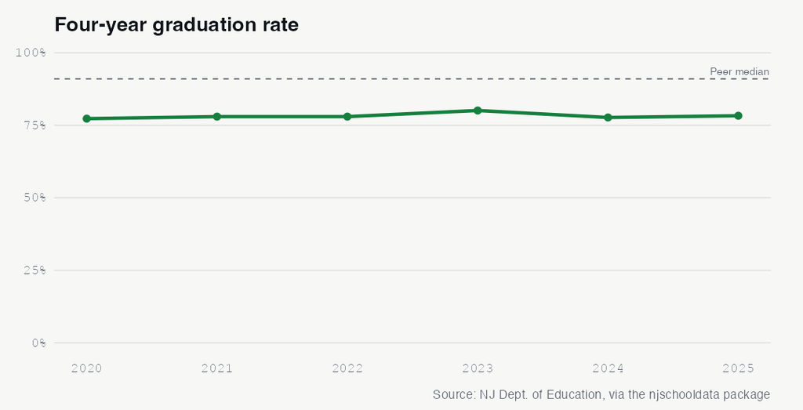

See the underlying data ›

No. 5 EQUITY

## A 35-Point Graduation Gap: Asian Students Finish at 95% in Jersey City, Students With Disabilities at 59%

Within one district, four-year graduation rates range from the mid-90s to under 60%, depending on the student group.

Jersey City’s overall 78.3% graduation rate for 2025 averages across student groups that finish high school at sharply different rates. At the top, students who are multiracial graduated at 96.4% and students who are Asian at 94.5%, with students who are white at 86.0%.

At the other end, students with disabilities graduated at 59.3%, students experiencing homelessness at 62.5%, and students who are Black at 71.3%. The gap between students who are Asian (94.5%) and students with disabilities (59.3%) is 35.2 percentage points; between students who are white (86.0%) and students who are Black (71.3%) it is 14.7 points. Students who are Hispanic, the district’s largest group, graduated at 73.6%, and students who are economically disadvantaged at 78.1% from a cohort of 1,350.

These are not fringe groups. The Black cohort numbered 522 students and the disabilities cohort 324, large enough that the gaps describe hundreds of students, not a handful. Read alongside the elementary-grade reading gaps in this same district, the divides look less like a senior-year problem and more like one that compounds across the whole K-12 span. The data leaves open the question of which supports might close them.

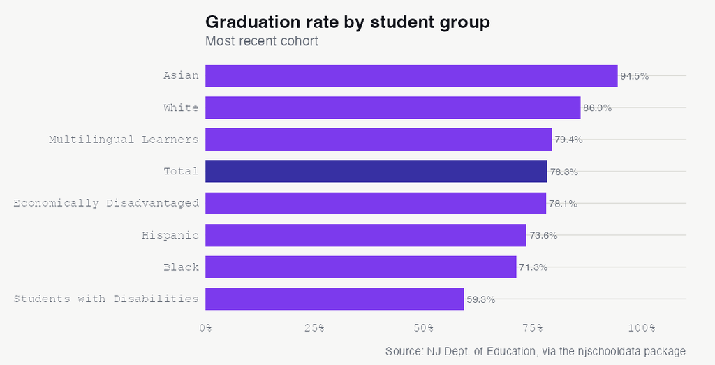

See the underlying data ›

No. 6 ATTENDANCE

## Nearly 1 in 4 Jersey City Students Was Chronically Absent in 2024, Above the 18% Peer Median

Absenteeism has eased from its pandemic peak but remains well above both the district’s pre-COVID level and the typical peer.

The encouraging trend in Jersey City’s attendance data is that the worst has passed. The share of students who were chronically absent climbed from 15.2% in 2019 to a peak of 29.6% in 2022, then fell to 25.6% in 2023 and 23.8% in 2024. The two-year improvement is real.

The harder comparison is to the rest of the district’s peer group. That 23.8% figure for 2024 still sits above the DFG B peer median of 18.3%, and it remains well above Jersey City’s own pre-pandemic baseline of 15.2% in 2019. Attendance has come down from crisis levels but has not returned to where it started, and it lags the districts Jersey City most resembles.

Chronic absenteeism tracks closely with the stalled academic recovery elsewhere in this data: the same 2022 year that marked peak absenteeism was also the trough for NJSLA math and reading. The figures cannot identify which students are missing the most school, but with nearly one in four students chronically absent, the question is whether attendance and proficiency climb back together, or stay stuck in tandem.

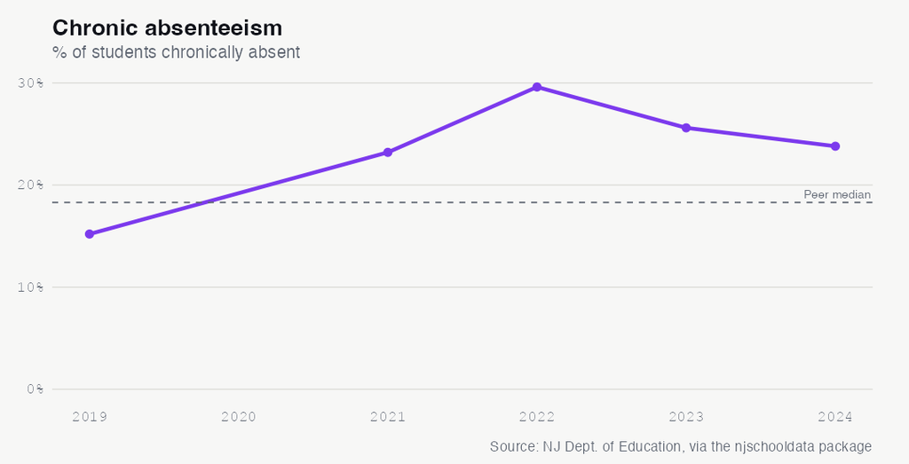

See the underlying data ›

No. 7 ACHIEVEMENT

## Jersey City Beats the State on Advanced Exams, 43% to 23%, Yet Two-Thirds of Its Middle-Graders Fail Math

The district’s top high-schoolers excel at college-level coursework even as the broad base of its elementary and middle students struggles with grade-level math.

In the same district and the same year, only 29.3% of students in grades 3-8 were proficient in math on the NJSLA, meaning roughly seven in ten were below grade level. The 43.4% AP/IB figure describes a self-selected cohort of high-achieving high-schoolers; the 29.3% NJSLA figure describes the entire tested population of younger students. Together they sketch a district with a strong ceiling and a weak floor.

The gap between these two numbers is the structural question for the board and superintendent Norma Fernandez. A district can run an excellent AP and IB program while most of its elementary students are not yet proficient, but the long-term pipeline depends on the floor rising to feed the ceiling. The data cannot say how many of today’s struggling third-graders will reach those AP seats, but it raises the doubt directly.

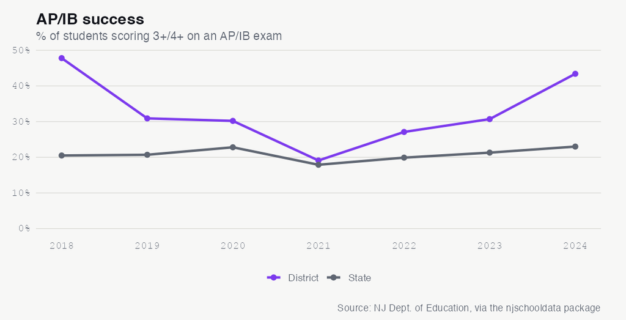

See the underlying data ›

No. 8 DEMOGRAPHICS

## Jersey City’s Black Enrollment Share Fell From 31.5% to 23.2% Since 2015 as Its White Share Rose 6.6 Points

The district’s single largest demographic change over the decade reshaped its Black enrollment, even as Hispanic students remained the largest group.

Over the same window, the share of students who are white rose from 11.4% to 18.0%, a gain of 6.6 points, and the share of students who are multiracial grew from 0.7% to 2.0%. Students who are Hispanic remained the largest single group throughout, holding near 38% (38.3% in 2015, 37.4% in 2026), while students who are Asian held steady around 18%.

The shift unfolds against well-documented change along Jersey City’s waterfront and downtown. The enrollment tables cannot say whether the falling Black share reflects families leaving the city, leaving its public schools, or broader population change. That is the question the numbers pose for a district whose neighborhoods are changing faster than most in the state.

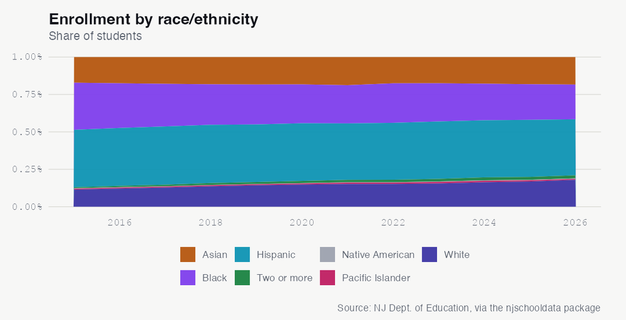

See the underlying data ›

No. 9 ENROLLMENT

## Jersey City Enrollment Fell to a Record-Low 25,307 in 2026, Down 9% From Its 2015 Peak

After a brief pandemic-era bump, the district has shed students for four straight years and now sits at its lowest count on record.

Jersey City Public Schools is smaller than it has been at any point in the data. The district counted 25,307 students in 2026, down from a 2015 peak of 27,810, a net loss of 2,503 students, or 9.0%, over the decade.

The decline has not been uniform. Enrollment slid steadily through the late 2010s, then briefly defied the pandemic: between 2019 and 2022 the district actually added 105 students, a 0.4% gain, even as many New Jersey districts lost children. But the recovery did not hold. Enrollment has fallen every year since, dropping from 26,890 in 2022 to 25,307 in 2026, a four-year string of declines of roughly 350 to 470 students each year.

A shrinking enrollment reshapes everything from staffing to state aid in a district of this size. The data cannot say whether the recent slide reflects families leaving the city, choosing charter or private options, or smaller incoming classes. The open question is whether 2026 marks a new floor or simply the latest step down.

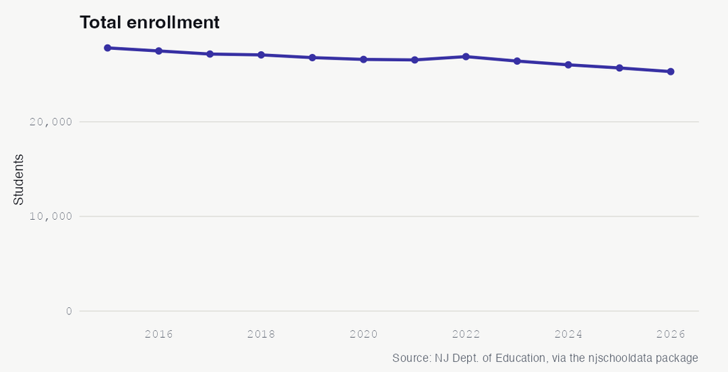

See the underlying data ›

No. 10 FINANCE

## Jersey City Staffs 1 Counselor for Every 385 Students and 1 Nurse for Every 444

Even as the district spends in the top tier of its peers, its support-staff ratios stretch counselors and nurses across hundreds of students each.

Those support ratios matter against the rest of this data. Counselors are central to the college-application and graduation work that Jersey City struggles with relative to peers, in a district where the four-year graduation rate sits in the 10th percentile of its group. A single counselor responsible for nearly 400 students has limited time per child for the transcript checks, credit-recovery planning and college outreach that move graduation rates.

The ratios sit beside a per-pupil spending figure of $22,219 that ranks in the 92nd percentile of the district’s peers, and a 2025 spending mix that put 56.2% toward classroom instruction. The data cannot say whether more counselors or nurses would change outcomes, but it frames a budgeting question: in a high-spending district, why are the adults closest to students’ graduation paths spread across so many?

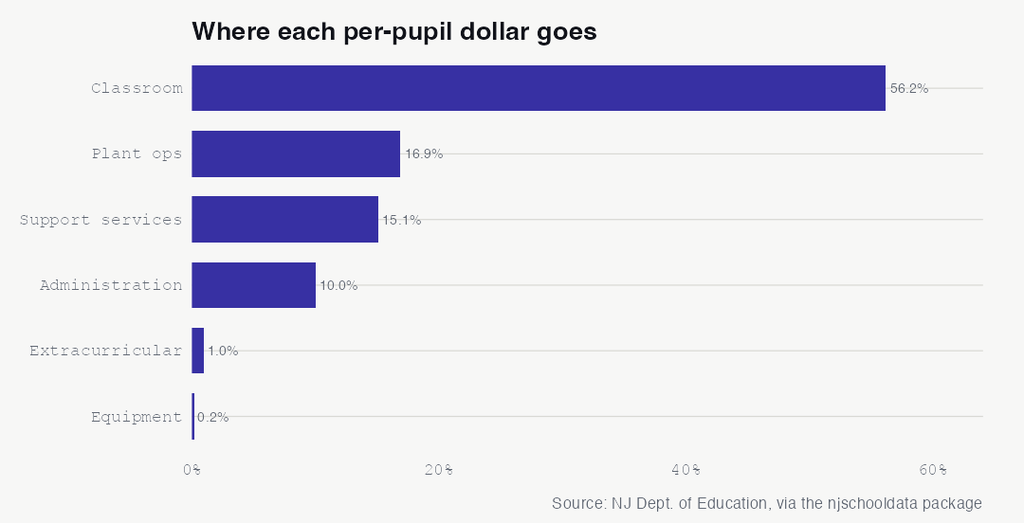

See the underlying data ›

## The Almanac

The full longitudinal record behind the stories above. Every number a reader can check.

### Enrollment (total)

| year | students | yoy | yoy_pct |
| --- | --- | --- | --- |
| 2015 | 27810 | NA | NA |
| 2016 | 27488 | -322 | -1.2 |
| 2017 | 27162 | -326 | -1.2 |
| 2018 | 27073 | -89 | -0.3 |
| 2019 | 26785 | -288 | -1.1 |
| 2020 | 26593 | -192 | -0.7 |
| 2021 | 26541 | -52 | -0.2 |
| 2022 | 26890 | 349 | 1.3 |
| 2023 | 26418 | -472 | -1.8 |
| 2024 | 26023 | -395 | -1.5 |
| 2025 | 25692 | -331 | -1.3 |
| 2026 | 25307 | -385 | -1.5 |

### Demographic share (%) by year

| end_year | white | black | hispanic | asian | native_american | pacific_islander | multiracial |
| --- | --- | --- | --- | --- | --- | --- | --- |
| 2015 | 11.4 | 31.5 | 38.3 | 17.1 | 0.3 | 0.6 | 0.7 |
| 2016 | 12.2 | 29.9 | 38.7 | 17.5 | 0.3 | 0.6 | 0.8 |
| 2017 | 12.8 | 28.5 | 38.9 | 17.9 | 0.2 | 0.7 | 1 |
| 2018 | 13.6 | 27.1 | 38.9 | 18.2 | 0.2 | 0.7 | 1.3 |
| 2019 | 14.3 | 26.7 | 38.5 | 18.3 | 0.2 | 0.7 | 1.3 |
| 2020 | 14.8 | 26 | 38.5 | 18.3 | 0.2 | 0.7 | 1.5 |
| 2021 | 15.2 | 25.5 | 37.7 | 18.8 | 0.2 | 0.9 | 1.6 |
| 2022 | 15.2 | 26.4 | 38 | 17.5 | 0.2 | 0.9 | 1.7 |
| 2023 | 15.5 | 25.5 | 38.3 | 17.5 | 0.3 | 1 | 1.7 |
| 2024 | 16.3 | 24.4 | 38.1 | 17.8 | 0.3 | 1 | 2 |
| 2025 | 16.8 | 23.8 | 38.1 | 18.1 | 0.3 | 0.8 | 1.9 |
| 2026 | 18 | 23.2 | 37.4 | 18.4 | 0.4 | 0.6 | 2 |

### Special populations (LEP, FRL)

| end_year | subgroup | students | pct |
| --- | --- | --- | --- |
| 2015 | lep | 4029 | 14.5 |
| 2015 | free_reduced_lunch | 21853 | 78.6 |
| 2016 | lep | 3494 | 12.7 |
| 2016 | free_reduced_lunch | 20505 | 74.6 |
| 2017 | lep | 3016 | 11.1 |
| 2017 | free_reduced_lunch | 20241 | 74.5 |
| 2018 | lep | 3628 | 13.4 |
| 2018 | free_reduced_lunch | 18943 | 70.0 |
| 2019 | lep | 3746 | 14.0 |
| 2019 | free_reduced_lunch | 19639 | 73.3 |
| 2020 | lep | 3803 | 14.3 |
| 2020 | free_reduced_lunch | 15956 | 60.0 |
| 2021 | lep | 3371 | 12.7 |
| 2021 | free_reduced_lunch | 15075 | 56.8 |
| 2022 | lep | 3361 | 12.5 |
| 2022 | free_reduced_lunch | 15112 | 56.2 |
| 2023 | lep | 3672 | 13.9 |
| 2023 | free_reduced_lunch | 14054 | 53.2 |
| 2024 | lep | 3721 | 14.3 |
| 2024 | free_reduced_lunch | 14313 | 55.0 |
| 2025 | lep | 3931 | 15.3 |
| 2025 | free_reduced_lunch | 16289 | 63.4 |
| 2026 | lep | 3973 | 15.7 |
| 2026 | free_reduced_lunch | 13640 | 53.9 |

### Graduation rate 4yr (total)

| year | grad_rate | cohort |
| --- | --- | --- |
| 2020 | 77.3 | 1676 |
| 2021 | 78 | 1680 |
| 2022 | 78 | 1631 |
| 2023 | 80.1 | 1576 |
| 2024 | 77.7 | 1691 |
| 2025 | 78.3 | 1831 |

### Graduation by subgroup (2025)

| subgroup | grad_rate | cohort |
| --- | --- | --- |
| multiracial | 96.4 | NA |
| asian | 94.5 | 289 |
| white | 86.0 | 235 |
| female | 81.7 | 854 |
| multilingual learners | 79.4 | 316 |
| total | 78.3 | 1831 |
| economically disadvantaged | 78.1 | 1350 |
| male | 75.2 | 977 |
| hispanic | 73.6 | 751 |
| black | 71.3 | 522 |
| students experiencing homelessness | 62.5 | 56 |
| students with disabilities | 59.3 | 324 |
| american indian | NA | NA |
| migrant students | NA | NA |
| military-connected students | NA | NA |
| non-binary/undesignated gender | NA | NA |
| students in foster care | NA | NA |

### NJGPA high-school proficiency (% proficient+)

| year | test | prof_above | valid |
| --- | --- | --- | --- |
| 2023 | ela | 74.9 | 1209 |
| 2023 | math | 39.3 | 1214 |
| 2024 | ela | 75.5 | 1344 |
| 2024 | math | 39.6 | 1334 |
| 2025 | ela | 70.6 | 1321 |
| 2025 | math | 42.6 | 1321 |

### NJGPA ELA by subgroup (2025)

[output not shown]

### NJSLA grades 3-8 proficiency (% proficient+, enrollment-weighted across grades)

| testing_year | test_name | prof |
| --- | --- | --- |
| 2017 | ela | 44.9 |
| 2017 | math | 30.9 |
| 2018 | math | 34.5 |
| 2019 | ela | 51.6 |
| 2019 | math | 34.2 |
| 2022 | ela | 41.9 |
| 2022 | math | 24.5 |
| 2023 | ela | 44.4 |
| 2023 | math | 27.1 |
| 2024 | ela | 45.4 |
| 2024 | math | 29.3 |

### NJSLA ELA proficiency by subgroup (2024, grades 3-8)

| subgroup | prof |
| --- | --- |
| asian | 79.1 |
| non_ed | 60.0 |
| other | 59.5 |
| white | 54.4 |
| female | 49.9 |
| total_population | 45.4 |
| male | 41.5 |
| hispanic | 38.2 |
| ed | 34.7 |
| black | 25.8 |
| MULTILINGUAL LEARNERS | 13.8 |
| lep_current_former | 11.7 |
| sped_accomodations | 11.4 |
| special_education | 7.7 |
| CURRENT - ML | NA |
| lep_current | NA |

### Chronic absenteeism (% chronically absent)

| year | chronic_pct |
| --- | --- |
| 2019 | 15.2 |
| 2021 | 23.2 |
| 2022 | 29.6 |
| 2023 | 25.6 |
| 2024 | 23.8 |

### Disciplinary removals

[output not shown]

### Police notifications (incident counts)

| year | violence | weapons | vandalism | substances | hib | other |
| --- | --- | --- | --- | --- | --- | --- |
| 2019 | 31 | 18 | 8 | 12 | 14 | 1 |
| 2020 | 7 | 7 | 0 | 8 | 4 | 0 |
| 2021 | 0 | 0 | 0 | 0 | 0 | 0 |
| 2022 | 7 | 12 | 2 | 4 | 6 | 0 |
| 2023 | 51 | 30 | 4 | 20 | 7 | 2 |
| 2024 | 55 | 17 | 5 | 31 | 14 | 5 |

### HIB (harassment/intimidation/bullying) investigations

| end_year | alleged | confirmed |
| --- | --- | --- |
| 2019 | 132 | 105 |
| 2020 | 110 | 61 |
| 2021 | 7 | 7 |
| 2022 | 133 | 101 |
| 2023 | 188 | 90 |
| 2024 | 156 | 121 |

### SAT participation (% of grade)

| year | sat_part | state_sat |
| --- | --- | --- |
| 2018 | 100 | 72.2 |
| 2019 | 100 | 72.1 |
| 2020 | 100 | 71.1 |
| 2021 | 47.1 | 45.4 |
| 2022 | 100 | 60.8 |
| 2023 | 100 | 61.9 |
| 2024 | 100 | 62.7 |

### AP/IB & dual enrollment (% of students)

| year | apib_coursework | apib_exam | ap3_ib4 | state_ap3_ib4 | dual |
| --- | --- | --- | --- | --- | --- |
| 2018 | 25.4 | 79.1 | 47.8 | 20.5 | 0 |
| 2019 | 51.9 | 75.3 | 30.9 | 20.7 | 0 |
| 2020 | 49 | 51 | 30.2 | 22.8 | 100 |
| 2021 | 31.8 | 38.2 | 19.1 | 17.9 | 0 |
| 2022 | 40.2 | 43 | 27.1 | 19.9 | 0 |
| 2023 | 14.7 | 34.7 | 30.7 | 21.3 | 0 |
| 2024 | 50.5 | 48.5 | 43.4 | 23 | 15.2 |

### Special education (raw rows; inspect for classification rate)

| end_year | district_id |
| --- | --- |
| 2024 | 2390 |

### Per-pupil spending (TGES actuals)

| year | per_pupil | rank | ade |
| --- | --- | --- | --- |
| 2014 | 18807 | 99 | 26274 |
| 2015 | 18154 | 98 | 25953 |
| 2016 | 17300 | 93 | 28325 |
| 2017 | 17706 | 90 | 28053 |
| 2018 | 19781 | 94 | 25147 |
| 2019 | 19177 | 90 | 25544 |
| 2020 | 18429 | 82 | 25250 |
| 2021 | 18847 | 82 | 24854 |
| 2022 | 21663 | 92 | 23025 |
| 2023 | 21234 | 87 | 23656 |
| 2024 | 22219 | 87 | 23351 |

### Spending composition shares (2025)

| classroom_share | support_services_share | administration_share | plant_ops_share | food_service_share | extracurricular_share | equipment_share |
| --- | --- | --- | --- | --- | --- | --- |
| 56.2 | 15.1 | 10 | 16.9 | NA | 1 | 0.2 |

### Staffing ratios

| end_year | student_teacher_district | student_admin_district | student_counselor_district | student_nurse_district |
| --- | --- | --- | --- | --- |
| 2024 | 12:1 | 179:1 | 385:1 | 444:1 |

Back to top